# Risk Factor Analysis

## Outcome Variable

**Outcome Variable:** ever_sstunted

## Predictor Variables

**Intervention Variable:** mbmi

**Adjustment Set:**

- arm
- W_mage
- meducyrs
- feducyrs
- hhwealth_quart
- W_nchldlt5
- brthmon
- W_parity
- delta_W_mage
- delta_meducyrs
- delta_feducyrs
- delta_hhwealth_quart
- delta_W_nchldlt5
- delta_brthmon
- delta_W_parity

## Stratifying Variables

The analysis was stratified on these variable(s):

- agecat
- studyid
- country

## Data Summary

| agecat | studyid | country | mbmi | ever_sstunted | n_cell | n |
| --- | --- | --- | --- | --- | --- | --- |
| 0-24 months | iLiNS-Zinc | BURKINA FASO | Normal weight | 0 | 2480 | 3216 |
| 0-24 months | iLiNS-Zinc | BURKINA FASO | Normal weight | 1 | 282 | 3216 |
| 0-24 months | iLiNS-Zinc | BURKINA FASO | Underweight | 0 | 398 | 3216 |
| 0-24 months | iLiNS-Zinc | BURKINA FASO | Underweight | 1 | 56 | 3216 |
| 0-24 months | JiVitA-3 | BANGLADESH | Normal weight | 0 | 13500 | 27105 |
| 0-24 months | JiVitA-3 | BANGLADESH | Normal weight | 1 | 3222 | 27105 |
| 0-24 months | JiVitA-3 | BANGLADESH | Underweight | 0 | 8606 | 27105 |
| 0-24 months | JiVitA-3 | BANGLADESH | Underweight | 1 | 1777 | 27105 |
| 0-24 months | LCNI-5 | MALAWI | Normal weight | 0 | 550 | 837 |
| 0-24 months | LCNI-5 | MALAWI | Normal weight | 1 | 142 | 837 |
| 0-24 months | LCNI-5 | MALAWI | Underweight | 0 | 110 | 837 |
| 0-24 months | LCNI-5 | MALAWI | Underweight | 1 | 35 | 837 |
| 0-24 months | MAL-ED | BANGLADESH | Normal weight | 0 | 176 | 254 |
| 0-24 months | MAL-ED | BANGLADESH | Normal weight | 1 | 46 | 254 |
| 0-24 months | MAL-ED | BANGLADESH | Underweight | 0 | 22 | 254 |
| 0-24 months | MAL-ED | BANGLADESH | Underweight | 1 | 10 | 254 |
| 0-24 months | MAL-ED | BRAZIL | Normal weight | 0 | 192 | 221 |
| 0-24 months | MAL-ED | BRAZIL | Normal weight | 1 | 19 | 221 |
| 0-24 months | MAL-ED | BRAZIL | Underweight | 0 | 8 | 221 |
| 0-24 months | MAL-ED | BRAZIL | Underweight | 1 | 2 | 221 |
| 0-24 months | MAL-ED | INDIA | Normal weight | 0 | 148 | 242 |
| 0-24 months | MAL-ED | INDIA | Normal weight | 1 | 45 | 242 |
| 0-24 months | MAL-ED | INDIA | Underweight | 0 | 36 | 242 |
| 0-24 months | MAL-ED | INDIA | Underweight | 1 | 13 | 242 |
| 0-24 months | MAL-ED | NEPAL | Normal weight | 0 | 217 | 238 |
| 0-24 months | MAL-ED | NEPAL | Normal weight | 1 | 21 | 238 |
| 0-24 months | MAL-ED | NEPAL | Underweight | 0 | 0 | 238 |
| 0-24 months | MAL-ED | NEPAL | Underweight | 1 | 0 | 238 |
| 0-24 months | MAL-ED | PERU | Normal weight | 0 | 225 | 290 |
| 0-24 months | MAL-ED | PERU | Normal weight | 1 | 60 | 290 |
| 0-24 months | MAL-ED | PERU | Underweight | 0 | 2 | 290 |
| 0-24 months | MAL-ED | PERU | Underweight | 1 | 3 | 290 |
| 0-24 months | MAL-ED | SOUTH AFRICA | Normal weight | 0 | 195 | 270 |
| 0-24 months | MAL-ED | SOUTH AFRICA | Normal weight | 1 | 67 | 270 |
| 0-24 months | MAL-ED | SOUTH AFRICA | Underweight | 0 | 5 | 270 |
| 0-24 months | MAL-ED | SOUTH AFRICA | Underweight | 1 | 3 | 270 |
| 0-24 months | MAL-ED | TANZANIA, UNITED REPUBLIC OF | Normal weight | 0 | 114 | 256 |
| 0-24 months | MAL-ED | TANZANIA, UNITED REPUBLIC OF | Normal weight | 1 | 128 | 256 |
| 0-24 months | MAL-ED | TANZANIA, UNITED REPUBLIC OF | Underweight | 0 | 6 | 256 |
| 0-24 months | MAL-ED | TANZANIA, UNITED REPUBLIC OF | Underweight | 1 | 8 | 256 |
| 0-24 months | NIH-Birth | BANGLADESH | Normal weight | 0 | 374 | 629 |
| 0-24 months | NIH-Birth | BANGLADESH | Normal weight | 1 | 149 | 629 |
| 0-24 months | NIH-Birth | BANGLADESH | Underweight | 0 | 59 | 629 |
| 0-24 months | NIH-Birth | BANGLADESH | Underweight | 1 | 47 | 629 |
| 0-24 months | NIH-Crypto | BANGLADESH | Normal weight | 0 | 603 | 755 |
| 0-24 months | NIH-Crypto | BANGLADESH | Normal weight | 1 | 84 | 755 |
| 0-24 months | NIH-Crypto | BANGLADESH | Underweight | 0 | 53 | 755 |
| 0-24 months | NIH-Crypto | BANGLADESH | Underweight | 1 | 15 | 755 |
| 0-24 months | PROBIT | BELARUS | Normal weight | 0 | 12850 | 13728 |
| 0-24 months | PROBIT | BELARUS | Normal weight | 1 | 355 | 13728 |
| 0-24 months | PROBIT | BELARUS | Underweight | 0 | 506 | 13728 |
| 0-24 months | PROBIT | BELARUS | Underweight | 1 | 17 | 13728 |
| 0-24 months | PROVIDE | BANGLADESH | Normal weight | 0 | 477 | 669 |
| 0-24 months | PROVIDE | BANGLADESH | Normal weight | 1 | 65 | 669 |
| 0-24 months | PROVIDE | BANGLADESH | Underweight | 0 | 98 | 669 |
| 0-24 months | PROVIDE | BANGLADESH | Underweight | 1 | 29 | 669 |
| 0-24 months | SAS-CompFeed | INDIA | Normal weight | 0 | 712 | 1407 |
| 0-24 months | SAS-CompFeed | INDIA | Normal weight | 1 | 316 | 1407 |
| 0-24 months | SAS-CompFeed | INDIA | Underweight | 0 | 231 | 1407 |
| 0-24 months | SAS-CompFeed | INDIA | Underweight | 1 | 148 | 1407 |
| 0-24 months | TanzaniaChild2 | TANZANIA, UNITED REPUBLIC OF | Normal weight | 0 | 2078 | 2345 |
| 0-24 months | TanzaniaChild2 | TANZANIA, UNITED REPUBLIC OF | Normal weight | 1 | 229 | 2345 |
| 0-24 months | TanzaniaChild2 | TANZANIA, UNITED REPUBLIC OF | Underweight | 0 | 34 | 2345 |
| 0-24 months | TanzaniaChild2 | TANZANIA, UNITED REPUBLIC OF | Underweight | 1 | 4 | 2345 |
| 0-24 months | ZVITAMBO | ZIMBABWE | Normal weight | 0 | 7629 | 9819 |
| 0-24 months | ZVITAMBO | ZIMBABWE | Normal weight | 1 | 1673 | 9819 |
| 0-24 months | ZVITAMBO | ZIMBABWE | Underweight | 0 | 394 | 9819 |
| 0-24 months | ZVITAMBO | ZIMBABWE | Underweight | 1 | 123 | 9819 |

The following strata were considered:

- agecat: 0-24 months, studyid: iLiNS-Zinc, country: BURKINA FASO
- agecat: 0-24 months, studyid: JiVitA-3, country: BANGLADESH
- agecat: 0-24 months, studyid: LCNI-5, country: MALAWI
- agecat: 0-24 months, studyid: MAL-ED, country: BANGLADESH
- agecat: 0-24 months, studyid: MAL-ED, country: BRAZIL
- agecat: 0-24 months, studyid: MAL-ED, country: INDIA
- agecat: 0-24 months, studyid: MAL-ED, country: NEPAL
- agecat: 0-24 months, studyid: MAL-ED, country: PERU
- agecat: 0-24 months, studyid: MAL-ED, country: SOUTH AFRICA
- agecat: 0-24 months, studyid: MAL-ED, country: TANZANIA, UNITED REPUBLIC OF
- agecat: 0-24 months, studyid: NIH-Birth, country: BANGLADESH
- agecat: 0-24 months, studyid: NIH-Crypto, country: BANGLADESH
- agecat: 0-24 months, studyid: PROBIT, country: BELARUS
- agecat: 0-24 months, studyid: PROVIDE, country: BANGLADESH
- agecat: 0-24 months, studyid: SAS-CompFeed, country: INDIA
- agecat: 0-24 months, studyid: TanzaniaChild2, country: TANZANIA, UNITED REPUBLIC OF
- agecat: 0-24 months, studyid: ZVITAMBO, country: ZIMBABWE

### Dropped Strata

Some strata were dropped due to rare outcomes:

- agecat: 0-24 months, studyid: MAL-ED, country: BRAZIL
- agecat: 0-24 months, studyid: MAL-ED, country: NEPAL
- agecat: 0-24 months, studyid: MAL-ED, country: PERU
- agecat: 0-24 months, studyid: MAL-ED, country: SOUTH AFRICA
- agecat: 0-24 months, studyid: TanzaniaChild2, country: TANZANIA, UNITED REPUBLIC OF

## Methods Detail

We're interested in the causal parameters $E[Y_a]$ for all values of $a \in \mathcal{A}$. These parameters represent the mean outcome if, possibly contrary to fact, we intervened to set all units to have $A=a$. Under the randomization and positivity assumptions, these are identified by the statistical parameters $\psi_a=E_W[E_{Y|A,W}(Y|A=a,W)]$. In addition, we're interested in the mean of $Y$, $E[Y]$ under no intervention (the observed mean). We will estimate these parameters by using SuperLearner to fit the relevant likelihood factors -- $E_{Y|A,W}(Y|A=a,W)$ and $p(A=a|W)$, and then updating our likelihood fit using a joint TMLE.

For unadjusted analyses ($W=\{\}$), initial likelihoods were estimated using Lrnr_glm to estimate the simple $E(Y|A)$ and Lrnr_mean to estimate $p(A)$. For adjusted analyses, a small library containing Lrnr_glmnet, Lrnr_xgboost, and Lrnr_mean was used.

Having estimated these parameters, we will then use the delta method to estimate relative risks and attributable risks relative to a prespecified baseline level of $A$.

# Results Detail

## Results Plots

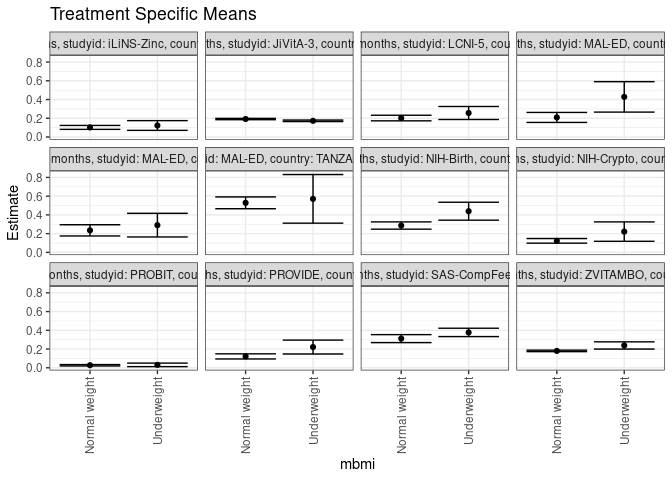

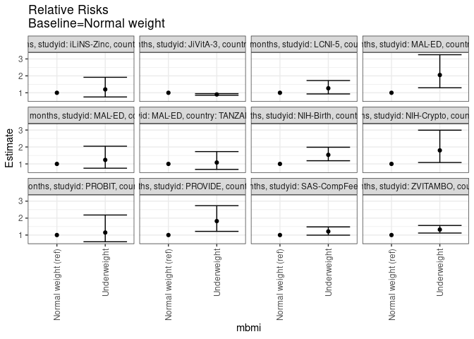

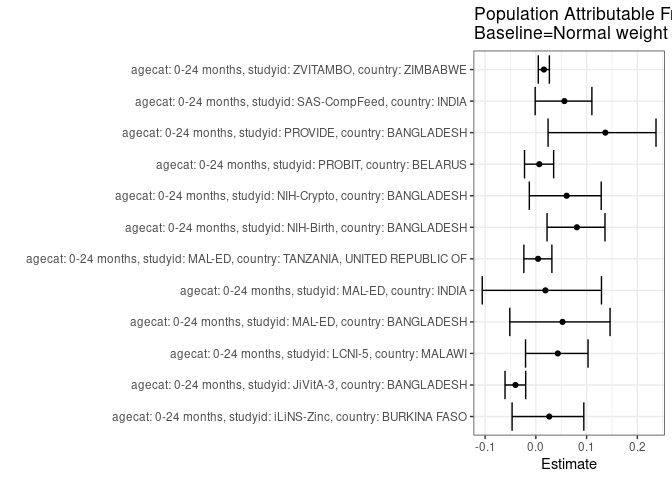

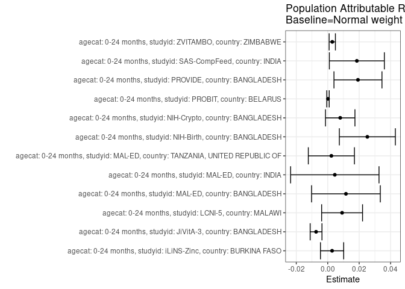

## Results Table

### Parameter: TSM

| agecat | studyid | country | intervention_level | baseline_level | estimate | ci_lower | ci_upper |
| --- | --- | --- | --- | --- | --- | --- | --- |
| 0-24 months | iLiNS-Zinc | BURKINA FASO | Normal weight | NA | 0.1023219 | 0.0812235 | 0.1234202 |
| 0-24 months | iLiNS-Zinc | BURKINA FASO | Underweight | NA | 0.1227023 | 0.0707895 | 0.1746150 |
| 0-24 months | JiVitA-3 | BANGLADESH | Normal weight | NA | 0.1918406 | 0.1849380 | 0.1987432 |
| 0-24 months | JiVitA-3 | BANGLADESH | Underweight | NA | 0.1725851 | 0.1644995 | 0.1806707 |
| 0-24 months | LCNI-5 | MALAWI | Normal weight | NA | 0.2023231 | 0.1723012 | 0.2323450 |
| 0-24 months | LCNI-5 | MALAWI | Underweight | NA | 0.2563206 | 0.1869690 | 0.3256723 |
| 0-24 months | MAL-ED | BANGLADESH | Normal weight | NA | 0.2088768 | 0.1554657 | 0.2622879 |
| 0-24 months | MAL-ED | BANGLADESH | Underweight | NA | 0.4282987 | 0.2658470 | 0.5907505 |
| 0-24 months | MAL-ED | INDIA | Normal weight | NA | 0.2351548 | 0.1752051 | 0.2951044 |
| 0-24 months | MAL-ED | INDIA | Underweight | NA | 0.2905430 | 0.1643689 | 0.4167170 |
| 0-24 months | MAL-ED | TANZANIA, UNITED REPUBLIC OF | Normal weight | NA | 0.5289256 | 0.4659123 | 0.5919389 |
| 0-24 months | MAL-ED | TANZANIA, UNITED REPUBLIC OF | Underweight | NA | 0.5714286 | 0.3116959 | 0.8311612 |
| 0-24 months | NIH-Birth | BANGLADESH | Normal weight | NA | 0.2863910 | 0.2475802 | 0.3252017 |
| 0-24 months | NIH-Birth | BANGLADESH | Underweight | NA | 0.4396030 | 0.3438352 | 0.5353708 |
| 0-24 months | NIH-Crypto | BANGLADESH | Normal weight | NA | 0.1231746 | 0.0985545 | 0.1477947 |
| 0-24 months | NIH-Crypto | BANGLADESH | Underweight | NA | 0.2216518 | 0.1180354 | 0.3252683 |
| 0-24 months | PROBIT | BELARUS | Normal weight | NA | 0.0269141 | 0.0195802 | 0.0342479 |
| 0-24 months | PROBIT | BELARUS | Underweight | NA | 0.0308920 | 0.0121210 | 0.0496630 |
| 0-24 months | PROVIDE | BANGLADESH | Normal weight | NA | 0.1212647 | 0.0938073 | 0.1487221 |
| 0-24 months | PROVIDE | BANGLADESH | Underweight | NA | 0.2211659 | 0.1469750 | 0.2953568 |
| 0-24 months | SAS-CompFeed | INDIA | Normal weight | NA | 0.3112436 | 0.2687605 | 0.3537267 |
| 0-24 months | SAS-CompFeed | INDIA | Underweight | NA | 0.3774407 | 0.3327653 | 0.4221161 |
| 0-24 months | ZVITAMBO | ZIMBABWE | Normal weight | NA | 0.1800170 | 0.1722037 | 0.1878302 |
| 0-24 months | ZVITAMBO | ZIMBABWE | Underweight | NA | 0.2382501 | 0.1995888 | 0.2769113 |

### Parameter: E(Y)

| agecat | studyid | country | intervention_level | baseline_level | estimate | ci_lower | ci_upper |
| --- | --- | --- | --- | --- | --- | --- | --- |
| 0-24 months | iLiNS-Zinc | BURKINA FASO | NA | NA | 0.1050995 | 0.0855497 | 0.1246493 |
| 0-24 months | JiVitA-3 | BANGLADESH | NA | NA | 0.1844309 | 0.1788328 | 0.1900291 |
| 0-24 months | LCNI-5 | MALAWI | NA | NA | 0.2114695 | 0.1837888 | 0.2391503 |
| 0-24 months | MAL-ED | BANGLADESH | NA | NA | 0.2204724 | 0.1693889 | 0.2715560 |
| 0-24 months | MAL-ED | INDIA | NA | NA | 0.2396694 | 0.1857746 | 0.2935643 |
| 0-24 months | MAL-ED | TANZANIA, UNITED REPUBLIC OF | NA | NA | 0.5312500 | 0.4700011 | 0.5924989 |
| 0-24 months | NIH-Birth | BANGLADESH | NA | NA | 0.3116057 | 0.2753823 | 0.3478292 |
| 0-24 months | NIH-Crypto | BANGLADESH | NA | NA | 0.1311258 | 0.1070332 | 0.1552185 |
| 0-24 months | PROBIT | BELARUS | NA | NA | 0.0270979 | 0.0199447 | 0.0342511 |
| 0-24 months | PROVIDE | BANGLADESH | NA | NA | 0.1405082 | 0.1141551 | 0.1668613 |
| 0-24 months | SAS-CompFeed | INDIA | NA | NA | 0.3297797 | 0.2987556 | 0.3608038 |
| 0-24 months | ZVITAMBO | ZIMBABWE | NA | NA | 0.1829107 | 0.1752637 | 0.1905577 |

### Parameter: RR

| agecat | studyid | country | intervention_level | baseline_level | estimate | ci_lower | ci_upper |
| --- | --- | --- | --- | --- | --- | --- | --- |
| 0-24 months | iLiNS-Zinc | BURKINA FASO | Normal weight | Normal weight | 1.0000000 | 1.0000000 | 1.0000000 |
| 0-24 months | iLiNS-Zinc | BURKINA FASO | Underweight | Normal weight | 1.1991794 | 0.7512599 | 1.9141597 |
| 0-24 months | JiVitA-3 | BANGLADESH | Normal weight | Normal weight | 1.0000000 | 1.0000000 | 1.0000000 |
| 0-24 months | JiVitA-3 | BANGLADESH | Underweight | Normal weight | 0.8996278 | 0.8517619 | 0.9501835 |
| 0-24 months | LCNI-5 | MALAWI | Normal weight | Normal weight | 1.0000000 | 1.0000000 | 1.0000000 |
| 0-24 months | LCNI-5 | MALAWI | Underweight | Normal weight | 1.2668875 | 0.9316973 | 1.7226666 |
| 0-24 months | MAL-ED | BANGLADESH | Normal weight | Normal weight | 1.0000000 | 1.0000000 | 1.0000000 |
| 0-24 months | MAL-ED | BANGLADESH | Underweight | Normal weight | 2.0504846 | 1.2945130 | 3.2479296 |
| 0-24 months | MAL-ED | INDIA | Normal weight | Normal weight | 1.0000000 | 1.0000000 | 1.0000000 |
| 0-24 months | MAL-ED | INDIA | Underweight | Normal weight | 1.2355393 | 0.7463539 | 2.0453532 |
| 0-24 months | MAL-ED | TANZANIA, UNITED REPUBLIC OF | Normal weight | Normal weight | 1.0000000 | 1.0000000 | 1.0000000 |
| 0-24 months | MAL-ED | TANZANIA, UNITED REPUBLIC OF | Underweight | Normal weight | 1.0803571 | 0.6753029 | 1.7283675 |
| 0-24 months | NIH-Birth | BANGLADESH | Normal weight | Normal weight | 1.0000000 | 1.0000000 | 1.0000000 |
| 0-24 months | NIH-Birth | BANGLADESH | Underweight | Normal weight | 1.5349751 | 1.1872486 | 1.9845453 |
| 0-24 months | NIH-Crypto | BANGLADESH | Normal weight | Normal weight | 1.0000000 | 1.0000000 | 1.0000000 |
| 0-24 months | NIH-Crypto | BANGLADESH | Underweight | Normal weight | 1.7994931 | 1.0821716 | 2.9922939 |
| 0-24 months | PROBIT | BELARUS | Normal weight | Normal weight | 1.0000000 | 1.0000000 | 1.0000000 |
| 0-24 months | PROBIT | BELARUS | Underweight | Normal weight | 1.1478025 | 0.6035467 | 2.1828477 |
| 0-24 months | PROVIDE | BANGLADESH | Normal weight | Normal weight | 1.0000000 | 1.0000000 | 1.0000000 |
| 0-24 months | PROVIDE | BANGLADESH | Underweight | Normal weight | 1.8238276 | 1.2165325 | 2.7342855 |
| 0-24 months | SAS-CompFeed | INDIA | Normal weight | Normal weight | 1.0000000 | 1.0000000 | 1.0000000 |
| 0-24 months | SAS-CompFeed | INDIA | Underweight | Normal weight | 1.2126857 | 0.9932063 | 1.4806658 |
| 0-24 months | ZVITAMBO | ZIMBABWE | Normal weight | Normal weight | 1.0000000 | 1.0000000 | 1.0000000 |
| 0-24 months | ZVITAMBO | ZIMBABWE | Underweight | Normal weight | 1.3234867 | 1.1188641 | 1.5655315 |

### Parameter: PAR

| agecat | studyid | country | intervention_level | baseline_level | estimate | ci_lower | ci_upper |
| --- | --- | --- | --- | --- | --- | --- | --- |
| 0-24 months | iLiNS-Zinc | BURKINA FASO | Normal weight | NA | 0.0027776 | -0.0046094 | 0.0101647 |
| 0-24 months | JiVitA-3 | BANGLADESH | Normal weight | NA | -0.0074097 | -0.0111686 | -0.0036508 |
| 0-24 months | LCNI-5 | MALAWI | Normal weight | NA | 0.0091464 | -0.0038659 | 0.0221587 |
| 0-24 months | MAL-ED | BANGLADESH | Normal weight | NA | 0.0115956 | -0.0102596 | 0.0334508 |
| 0-24 months | MAL-ED | INDIA | Normal weight | NA | 0.0045146 | -0.0235936 | 0.0326229 |
| 0-24 months | MAL-ED | TANZANIA, UNITED REPUBLIC OF | Normal weight | NA | 0.0023244 | -0.0123398 | 0.0169886 |
| 0-24 months | NIH-Birth | BANGLADESH | Normal weight | NA | 0.0252147 | 0.0073997 | 0.0430298 |
| 0-24 months | NIH-Crypto | BANGLADESH | Normal weight | NA | 0.0079512 | -0.0014145 | 0.0173170 |
| 0-24 months | PROBIT | BELARUS | Normal weight | NA | 0.0001838 | -0.0005832 | 0.0009508 |
| 0-24 months | PROVIDE | BANGLADESH | Normal weight | NA | 0.0192435 | 0.0039819 | 0.0345052 |
| 0-24 months | SAS-CompFeed | INDIA | Normal weight | NA | 0.0185361 | 0.0010451 | 0.0360270 |
| 0-24 months | ZVITAMBO | ZIMBABWE | Normal weight | NA | 0.0028937 | 0.0008931 | 0.0048943 |

### Parameter: PAF

| agecat | studyid | country | intervention_level | baseline_level | estimate | ci_lower | ci_upper |
| --- | --- | --- | --- | --- | --- | --- | --- |
| 0-24 months | iLiNS-Zinc | BURKINA FASO | Normal weight | NA | 0.0264287 | -0.0467946 | 0.0945301 |
| 0-24 months | JiVitA-3 | BANGLADESH | Normal weight | NA | -0.0401760 | -0.0607309 | -0.0200194 |
| 0-24 months | LCNI-5 | MALAWI | Normal weight | NA | 0.0432516 | -0.0202940 | 0.1028395 |
| 0-24 months | MAL-ED | BANGLADESH | Normal weight | NA | 0.0525944 | -0.0513162 | 0.1462346 |
| 0-24 months | MAL-ED | INDIA | Normal weight | NA | 0.0188370 | -0.1056669 | 0.1293210 |
| 0-24 months | MAL-ED | TANZANIA, UNITED REPUBLIC OF | Normal weight | NA | 0.0043753 | -0.0236201 | 0.0316050 |
| 0-24 months | NIH-Birth | BANGLADESH | Normal weight | NA | 0.0809188 | 0.0220640 | 0.1362315 |
| 0-24 months | NIH-Crypto | BANGLADESH | Normal weight | NA | 0.0606382 | -0.0128553 | 0.1287989 |
| 0-24 months | PROBIT | BELARUS | Normal weight | NA | 0.0067839 | -0.0223250 | 0.0350640 |
| 0-24 months | PROVIDE | BANGLADESH | Normal weight | NA | 0.1369566 | 0.0240759 | 0.2367808 |
| 0-24 months | SAS-CompFeed | INDIA | Normal weight | NA | 0.0562074 | -0.0013188 | 0.1104287 |
| 0-24 months | ZVITAMBO | ZIMBABWE | Normal weight | NA | 0.0158204 | 0.0048328 | 0.0266867 |